# Online Retail Analysis

Prateek Singh

2025-04-30

Importing libraries for data cleaning so as to perform an accurate and reliable analysis by removing errors and inaccuracies, tackling missing values and to ensure that the data is consistent. These tools would also help me make the data set of better quality.

```r
library(tidyverse)
library(dplyr)
library(lubridate)
```

Importing library for data visualization so I am able to convey my insights, which I have gained from the analyzing the data set, to the people who are unaware with the data set.

```r
library(ggplot2)
```

Importing the required data set into a variable, so we can work with it.

```r
onlineRetail <- read.csv('Online Retail.csv')
```

# Online Sales Analysis

## 1 Introduction

This is a transaction data set which contains all the transactions occurring between 01/12/2010 and 09/12/2011 for a UK-based and registered non-store online retail. The company mainly sells unique all-occasion gifts. Many customers of the company are wholesalers. The aim of the analysis is to explore key trends, uncover opportunities for growth, identify strengths and make data driven decision to optimize the online sales. The data sourced used was Online Sales, https://archive.ics.uci.edu/dataset/352/online+retail ., by Daqing Chen. The data set has 8 citations. The data set is licensed under the Creative Commons Attribution 4.0 International license.

```r
head(onlineRetail)
```

```
##   InvoiceNo StockCode                     Description Quantity      InvoiceDate
## 1    536381     71270                 PHOTO CLIP LINE        1 01-12-2010 09:41
## 2    536381     22262           FELT EGG COSY CHICKEN        1 01-12-2010 09:41
## 3    536381     22637           PIGGY BANK RETROSPOT         1 01-12-2010 09:41
## 4    536381     21166      COOK WITH WINE METAL SIGN         1 01-12-2010 09:41
## 5    536381    37444A YELLOW BREAKFAST CUP AND SAUCER        1 01-12-2010 09:41
## 6    536381    37444C  PINK BREAKFAST CUP AND SAUCER         1 01-12-2010 09:41
##   UnitPrice CustomerID        Country
## 1         1      15311 United Kingdom
## 2         1      15311 United Kingdom
## 3         3      15311 United Kingdom
## 4         2      15311 United Kingdom
## 5         3      15311 United Kingdom
## 6         3      15311 United Kingdom
```

```r
summary(onlineRetail)
```

```
##   InvoiceNo          StockCode         Description           Quantity
##  Length:531283      Length:531283      Length:531283      Min.   :    1.00
##  Class :character   Class :character   Class :character   1st Qu.:    1.00
##  Mode  :character   Mode  :character   Mode  :character   Median :    3.00
##                                                           Mean   :   10.66
##                                                           3rd Qu.:   10.00
##                                                           Max.   :80995.00
##
##  InvoiceDate          UnitPrice           CustomerID       Country
##  Length:531283      Min.   :    0.000   Min.   :12346    Length:531283
##  Class :character   1st Qu.:    1.000   1st Qu.:13969    Class :character
##  Mode  :character   Median :    2.000   Median :15159    Mode  :character
##                     Mean   :    3.895   Mean   :15294
##                     3rd Qu.:    4.000   3rd Qu.:16795
##                     Max.   :13541.000   Max.   :18287
##                                         NA's   :133359
```

## 2 Preparation

Changing the datatypes of the `InvoiceNo` and `StockCode` to integer from Character.

```r
onlineRetail <-  mutate(onlineRetail, InvoiceNo = as.integer(InvoiceNo),
                        StockCode = as.integer(StockCode))
```

Making the `InvoiceDate` into date-format from character for accurate sorting and perform complex functions.

```r
onlineRetail$InvoiceDate <- dmy_hm(onlineRetail$InvoiceDate)
```

Adding more columns to do an in-depth analysis of the data.

```r
onlineRetail$month <- month(onlineRetail$InvoiceDate)
onlineRetail$date <- as.Date(onlineRetail$InvoiceDate)
onlineRetail$weekD <- wday(onlineRetail$InvoiceDate, label = TRUE)
onlineRetail$time <- hour(onlineRetail$InvoiceDate)
onlineRetail$totalAmount <- (onlineRetail$Quantity * onlineRetail$UnitPrice)
```

Making another table to store the data after dropping the repeated values, so we can refer back to the original data set if required.

```r
onlineRetailV2 <- onlineRetail %>%  distinct()
```

Now checking for null values in the columns which are essential for an accurate analysis.

```r
sum(is.na(onlineRetailV2$StockCode))
```

```
## [1] 52783
```

```r
sum(is.na(onlineRetailV2$Quantity))
```

```
## [1] 0
```

```r
sum(is.na(onlineRetailV2$UnitPrice))
```

```
## [1] 0
```

```r
sum(is.na(onlineRetailV2$CustomerID))
```

```
## [1] 133282
```

```r
sum(is.na(onlineRetailV2$Country))
```

```
## [1] 0
```

We find that there are several key values that are missing and finally decided to drop all those rows which have these values missing.

```r
onlineRetailV2 <- na.omit(onlineRetailV2)
```

Since the `UnitPrice` cannot be zero, hence dropping all the rows which have `UnitPrice` as zero and storing it in another variable.

```r
onlineRetailV3 <- subset(onlineRetailV2, !(onlineRetailV2$UnitPrice = 0))
```

## 3 Data Overview

Firstly we will try to find some pattern in the Weekly purchases done by business.

```r
onlineRetailV3 %>% group_by(weekD) %>% summarise(sales = sum(totalAmount))
```

```
## # A tibble: 6 × 2
##   weekD   sales
##   <ord>   <int>
## 1 Sun    690978
## 2 Mon   1174256
## 3 Tue   1499136
## 4 Wed   1385562
## 5 Thu   1749249
## 6 Fri   1334682
```

```r
onlineRetailV3 %>%  group_by(StockCode) %>%  filter(weekD== 'Thu') %>%
  summarise(sales = sum(totalAmount)) %>% arrange(desc(sales)) %>% top_n(5)
```

```
## # A tibble: 5 × 2
##   StockCode sales
##       <int> <int>
## 1     22423 39861
## 2     84879 16184
## 3     47566 14600
## 4     23084 12126
## 5     23173 11842
```

We see that `StockCode 22423` had the most sales on Thursdays.

Does the quantity sold on the Thursdays go hand in hand with the revenue generated on Thursdays?

```r
onlineRetailV3 %>%  group_by(StockCode) %>%  filter(weekD== 'Thu') %>%
  summarise(quantity = sum(Quantity)) %>% arrange(desc(quantity)) %>% top_n(5)
```

```
## # A tibble: 5 × 2
##   StockCode quantity
##       <int>    <int>
## 1     84077    18107
## 2     22197    11774
## 3     84879    11160
## 4     22492     9288
## 5     21212     7947
```

On checking the quantity of products sold on Thursdays, we observe an *irregularity*. The irregularity was caused because the products which are priced lower sold in large quantities, while the products which were priced higher sold lesser, but they generated most of the revenue.

Does the Thursday pattern(high sales on Thursdays) is consistent throughout the year? or there’s something hidden ? So lets get the sales on weekdays for all the months and getting only top 3 from each week

```r
onlineRetailV3 %>%  select(c(month, weekD, totalAmount)) %>%  group_by(month, weekD) %>%
  summarise(sales = sum(totalAmount)) %>% arrange(desc(sales)) %>%  slice(1:3) %>%
  print(n = 36)
```

```
## # A tibble: 36 × 3
## # Groups:   month [12]
##    month weekD  sales
##    <dbl> <ord>  <int>
##  1     1 Tue   154992
##  2     1 Fri    91905
##  3     1 Thu    76877
##  4     2 Tue    95554
##  5     2 Mon    83821
##  6     2 Thu    64970
##  7     3 Thu   134425
##  8     3 Tue   102260
##  9     3 Wed    97485
## 10     4 Thu    88091
## 11     4 Tue    79478
```

[output cut: 25 more lines]

Did the `StockCode`, which made the maximum sales on Thursday, also made the maximum sale throughout the year ? Lets find out about that.

```r
onlineRetailV3 %>%  group_by(StockCode) %>%  summarise(revenue = sum(totalAmount)) %>%
  arrange(desc(revenue)) %>%  slice(1:5)
```

```
## # A tibble: 5 × 2
##   StockCode revenue
##       <int>   <int>
## 1     23843  161990
## 2     22423  143646
## 3     23166   77916
## 4     47566   68372
## 5     84879   57270
```

Since the sales go maximum during the last 4 months of the year, and during the last 3 months days other than Thursdays have the maximum amount of sales, that might explain why the Item sold maximum on Thursdays is not on the top revenue generating list.

Lets find out the top 5 customers from each country with their revenue generated by each Customer.

```r
onlineRetailV3 %>% group_by(Country, CustomerID) %>% summarise(revenue = sum(totalAmount)) %>%
  arrange(desc(revenue)) %>% slice(1:5) %>%  print(n=132)
```

```
## # A tibble: 132 × 3
## # Groups:   Country [37]
##     Country              CustomerID revenue
##     <chr>                     <int>   <int>
##   1 Australia                 12415  117372
##   2 Australia                 12431    5064
##   3 Australia                 12388    2577
##   4 Australia                 12424    1774
##   5 Australia                 12393    1650
##   6 Austria                   12360    2182
##   7 Austria                   12865    1407
##   8 Austria                   12818     960
##   9 Austria                   12453     653
##  10 Austria                   12374     595
##  11 Bahrain                   12355     320
```

[output cut: 121 more lines]

From the table above we get an idea of the high value customers from each country. Now we want to look for the Customers who purchased the maximum number of Items from the business so we can get an idea of the frequent low spending customers.

```r
onlineRetailV3 %>%  group_by(CustomerID) %>%  summarise(no = n()) %>%
  filter(no > 1) %>%  arrange(desc(no)) %>%  slice(1:5)
```

```
## # A tibble: 5 × 2
##   CustomerID    no
##        <int> <int>
## 1      17841  6940
## 2      14911  5104
## 3      14096  4558
## 4      12748  3969
## 5      14606  2328
```

Checking for the number of purchases done by the Customers and arranging them into descending order.

```r
onlineRetailV3 %>%  group_by(CustomerID, InvoiceDate) %>%  summarise(cnt = n()) %>%
  count() %>%  arrange(desc(n)) %>%  top_n(5)
```

```
## # A tibble: 4,315 × 2
## # Groups:   CustomerID [4,315]
##    CustomerID     n
##         <int> <int>
##  1      12748   200
##  2      14911   198
##  3      17841   122
##  4      14606    91
##  5      15311    91
##  6      13089    90
##  7      12971    82
##  8      14646    72
##  9      16029    59
## 10      13408    58
## # ℹ 4,305 more rows
```

We see that there are 2 customers that have significantly more number of purchases than the other customers. Now we are going to determine the 5 highest revenue generating dates of the month.

```r
onlineRetailV3 %>%  group_by(month, date) %>% summarise(revenue = sum(totalAmount)) %>% arrange(desc(revenue)) %>% slice(1:5) %>%  print(n= 60)
```

```
## # A tibble: 60 × 3
## # Groups:   month [12]
##    month date       revenue
##    <dbl> <date>       <int>
##  1     1 2011-01-18   82882
##  2     1 2011-01-11   41767
##  3     1 2011-01-14   36747
##  4     1 2011-01-06   29473
##  5     1 2011-01-05   22409
##  6     2 2011-02-15   35202
##  7     2 2011-02-21   29933
##  8     2 2011-02-22   26267
##  9     2 2011-02-01   21794
## 10     2 2011-02-16   21530
## 11     3 2011-03-29   34589
```

[output cut: 49 more lines]

Now are going back to look at the monthly sales and find some trends in the data.

```r
onlineRetailV3 %>%  group_by(month) %>%  summarise(sales = sum(totalAmount)) %>%  top_n(5)
```

```
## # A tibble: 5 × 2
##   month   sales
##   <dbl>   <int>
## 1     5  596946
## 2     9  857744
## 3    10  909305
## 4    11 1027161
## 5    12  973053
```

We see that last 3 months have considerable more sales than the other months. While we see a drop in the sales in the initial months of the year.

From the data, I would speculate that people purchase few items during winters, hence the business purchasing from us reduces its purchases while the reverse is true during the other months but also that Festivals/Special occasions become a bigger factor during the last quarter of the year.

What was the quantity sold?

```r
onlineRetailV3 %>%  group_by(month) %>%  summarise(quantity = sum(Quantity)) %>% top_n(5)
```

```
## # A tibble: 5 × 2
##   month quantity
##   <dbl>    <int>
## 1     8   366036
## 2     9   507136
## 3    10   551375
## 4    11   627970
## 5    12   554265
```

We see a similar trend over here that last 3 months have significantly high sales, while the initial months have the least.

What were the things sold? Lets know more about them.

```r
onlineRetailV3[order(onlineRetailV3$Quantity, decreasing = TRUE),] %>% top_n(5)
```

```
##   InvoiceNo StockCode                         Description Quantity
## 1    581483     23843         PAPER CRAFT , LITTLE BIRDIE    80995
## 2    541431     23166      MEDIUM CERAMIC TOP STORAGE JAR    74215
## 3    540815     21108  FAIRY CAKE FLANNEL ASSORTED COLOUR     3114
## 4    550461     21108  FAIRY CAKE FLANNEL ASSORTED COLOUR     3114
## 5    567423     23243 SET OF TEA COFFEE SUGAR TINS PANTRY     1412
## 6    556444     22502      PICNIC BASKET WICKER 60 PIECES       60
##           InvoiceDate UnitPrice CustomerID        Country month       date
## 1 2011-12-09 09:15:00         2      16446 United Kingdom    12 2011-12-09
## 2 2011-01-18 10:01:00         1      12346 United Kingdom     1 2011-01-18
## 3 2011-01-11 12:55:00         2      15749 United Kingdom     1 2011-01-11
## 4 2011-04-18 13:20:00         2      15749 United Kingdom     4 2011-04-18
## 5 2011-09-20 11:05:00         5      17450 United Kingdom     9 2011-09-20
## 6 2011-06-10 15:28:00       650      15098 United Kingdom     6 2011-06-10
##   weekD time totalAmount
## 1   Fri    9      161990
## 2   Tue   10       74215
## 3   Tue   12        6228
## 4   Mon   13        6228
## 5   Tue   11        7060
## 6   Fri   15       39000
```

Now we would like to see the countries with least amount of unit sold, so we could get an idea of countries where our business is under performing.

```r
onlineRetailV3 %>%  group_by(Country) %>%
  summarise(soldUnits = sum(Quantity)) %>%  arrange(soldUnits, FALSE) %>% head(5)
```

```
## # A tibble: 5 × 2
##   Country      soldUnits
##   <chr>            <int>
## 1 Saudi Arabia        80
## 2 Bahrain            230
## 3 Brazil             323
## 4 RSA                330
## 5 Lebanon            374
```

We see that Saudi Arabia has the minimum amount of units sold, followed by Bahrain, Brazil…

```r
onlineRetailV3 %>%  group_by(Country) %>%
  summarise(revenueGenerated = sum(totalAmount)) %>%  arrange(revenueGenerated, FALSE)%>% head(5)
```

```
## # A tibble: 5 × 2
##   Country            revenueGenerated
##   <chr>                         <int>
## 1 Saudi Arabia                    148
## 2 Bahrain                         406
## 3 Czech Republic                  666
## 4 RSA                             944
## 5 European Community              996
```

We see a similar trend that Saudi Arabia has the minimum revenue generated of all the countries.

Lets go back and take a look at the countries with the maximum revenue generated (except United Kingdom)

```r
onlineRetailV3 %>%  group_by(Country) %>%
  summarise(revenueGenerated = sum(Quantity * UnitPrice)) %>%
  arrange(desc(revenueGenerated)) %>% filter(Country != "United Kingdom") %>% head(5)
```

```
## # A tibble: 5 × 2
##   Country     revenueGenerated
##   <chr>                  <int>
## 1 Netherlands           262628
## 2 EIRE                  238827
## 3 Germany               189375
## 4 France                176569
## 5 Australia             130333
```

Having seen the highest revenue generated, let us observe the least revenue generating countries.

```r
onlineRetailV3 %>%  group_by(Country) %>%
  summarise(revenueGenerated = sum(Quantity * UnitPrice)) %>%
  arrange((revenueGenerated)) %>% filter(Country != "United Kingdom")
```

```
## # A tibble: 36 × 2
##    Country              revenueGenerated
##    <chr>                           <int>
##  1 Saudi Arabia                      148
##  2 Bahrain                           406
##  3 Czech Republic                    666
##  4 RSA                               944
##  5 European Community                996
##  6 Brazil                           1086
##  7 Lithuania                        1522
##  8 Malta                            1630
##  9 Lebanon                          1703
## 10 United Arab Emirates             1798
## # ℹ 26 more rows
```

We observe that `Saudi Arabia` has the minimum amount of sales.

```r
onlineRetailV3 %>%  group_by(Country) %>%
  summarise(soldUnits = sum(Quantity)) %>%  arrange(desc(soldUnits)) %>%
  filter(Country != "United Kingdom")%>% head(5)
```

```
## # A tibble: 5 × 2
##   Country     soldUnits
##   <chr>           <int>
## 1 Netherlands    193375
## 2 EIRE           131328
## 3 Germany        111533
## 4 France         106389
## 5 Australia       82085
```

Now we are going to take a look at the top 3 items from each country, according to their quantities sold.

```r
onlineRetailV3 %>%  group_by(Country) %>%  arrange(desc(Quantity)) %>%
  top_n(3) %>%  slice(1:3)
```

```
## # A tibble: 111 × 13
## # Groups:   Country [37]
##    InvoiceNo StockCode Description        Quantity InvoiceDate         UnitPrice
##        <int>     <int> <chr>                 <int> <dttm>                  <int>
##  1    565145     22492 "MINI PAINT SET V…     1152 2011-09-01 13:50:00         1
##  2    576394     23084 "RABBIT NIGHT LIG…      960 2011-11-15 10:32:00         2
##  3    563614     22940 "FELTCRAFT CHRIST…      336 2011-08-18 08:51:00         4
##  4    547493     22582 "PACK OF 6 SWEETI…      144 2011-03-23 12:06:00         2
##  5    547493     22584 "PACK OF 6 PANNET…      144 2011-03-23 12:06:00         2
##  6    581232     20679 "EDWARDIAN PARASO…       24 2011-12-08 10:26:00         6
##  7    552449     23076 "ICE CREAM SUNDAE…       96 2011-05-09 13:49:00         1
##  8    552449     23077 "DOUGHNUT LIP GLO…       60 2011-05-09 13:49:00         1
##  9    552449     22649 "STRAWBERRY FAIRY…        8 2011-05-09 13:49:00         5
## 10    565246     22328 "ROUND SNACK BOXE…       48 2011-09-02 10:27:00         3
## # ℹ 101 more rows
## # ℹ 7 more variables: CustomerID <int>, Country <chr>, month <dbl>,
## #   date <date>, weekD <ord>, time <int>, totalAmount <int>
```

## 4 Data Visualization

Firstly, lets visualize the revenue generated by the top 5 countries except the United Kingdom as it has exponentially more sales in United Kingdom and the company/business is also based in United Kingdom.

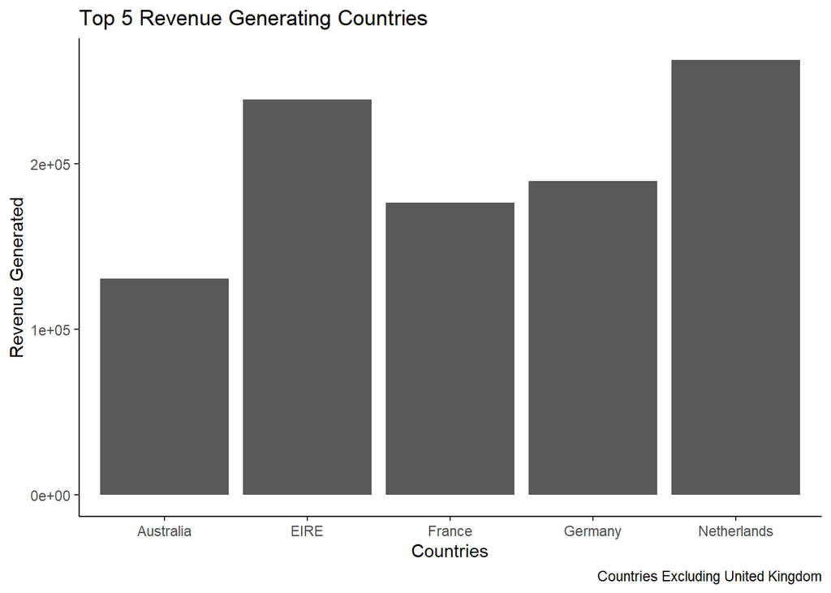

```r
onlineRetailV3 %>%  group_by(Country) %>%
  summarise(revenueGenerated = sum(Quantity * UnitPrice)) %>%
  arrange(desc(revenueGenerated)) %>%
  filter(Country != "United Kingdom") %>% top_n(5) %>%
  ggplot(aes(x = Country, y = revenueGenerated)) + geom_col(position = "dodge") +
  labs(x = "Countries", y = "Revenue Generated", title = "Top 5 Revenue Generating Countries",
       caption = "Countries Excluding United Kingdom")+
  theme_classic()
```

We see that Netherlands has the highest amount of Revenue generated followed by EIRE, Germany … Who are the least Revenue generating countries? Just curious!

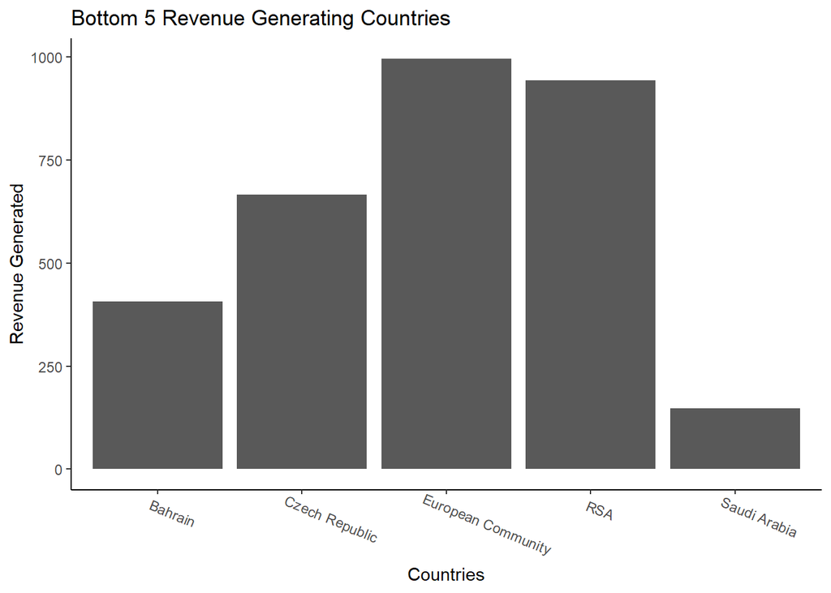

```r
onlineRetailV3 %>%  group_by(Country) %>%
  summarise(revenueGenerated = sum(Quantity * UnitPrice)) %>%
  arrange(revenueGenerated) %>% filter(Country != "United Kingdom") %>% slice(1:5) %>%
  ggplot(aes(x = Country, y = revenueGenerated)) + geom_col(position = "dodge") +
  labs(x = "Countries", y = "Revenue Generated", title = "Bottom 5 Revenue Generating Countries")+
  theme_classic() + theme(axis.text.x = element_text(angle = -22.5, vjust = 0.1, hjust = 0.2))
```

We observe(as before) that Saudi Arabia has the minimum amount of Revenue generated.

What were the sales throughout the week?

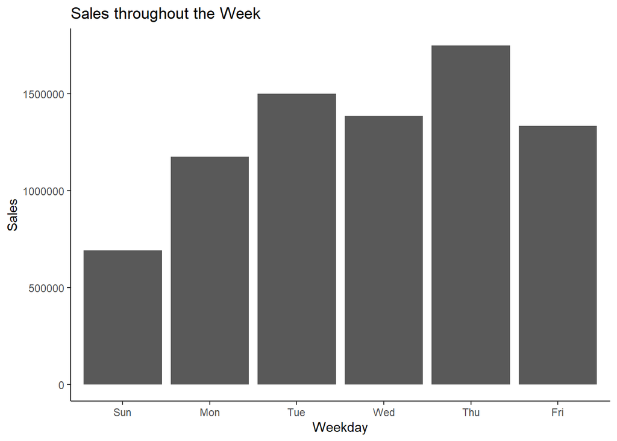

```r
onlineRetailV3 %>% group_by(weekD) %>% summarise(sales = sum(totalAmount)) %>%
  ggplot(aes(x = weekD, y = sales)) + geom_col(position = "dodge") +
  labs(x= "Weekday", y = "Sales", title = "Sales throughout the Week") +
  theme_classic()
```

We see a trend that the Revenue generated reaches its peak during the mid week days, while seeing a minimum during the weekends.

Does the quantity sold throughout the week follow the same trend as the revenue generated ?

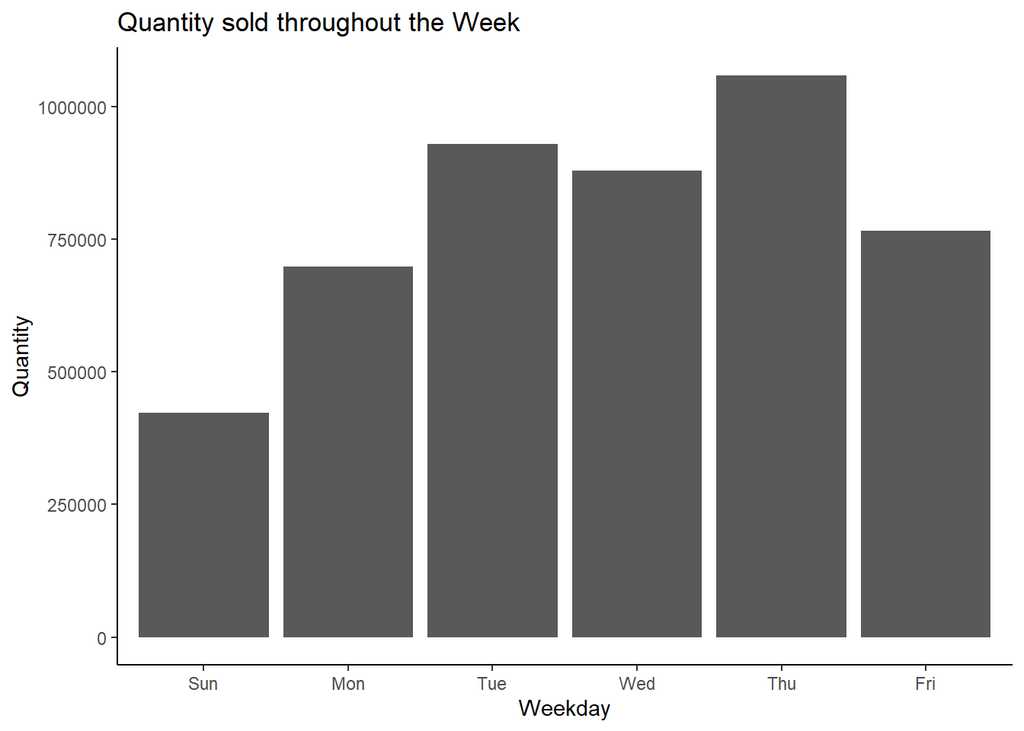

```r
onlineRetailV3 %>% group_by(weekD) %>% summarise(sales = sum(Quantity)) %>%
  ggplot(aes(x = weekD, y = sales)) + geom_col(position = "dodge") +
  labs(x= "Weekday", y = "Quantity", title = "Quantity sold throughout the Week") +
  theme_classic()
```

Here also, we see a similar trend, that the quantity sold on a day sees a maximum on the weekday while having a minimum during the weekends.

What are the top 5 selling items?

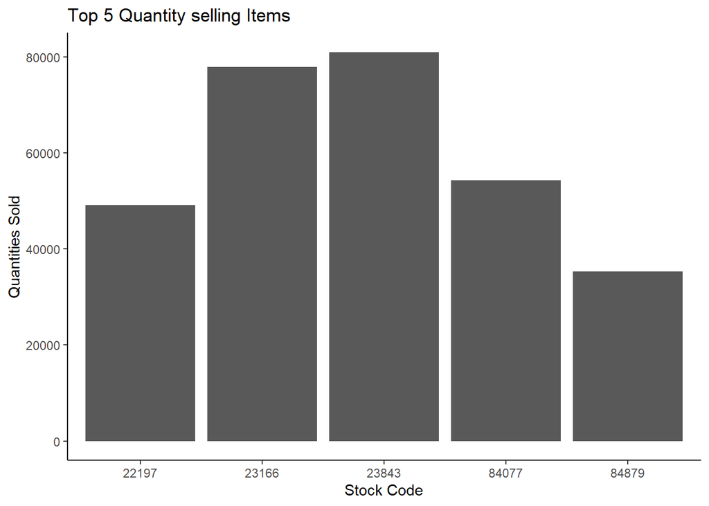

```r
onlineRetailV3 %>%  group_by(StockCode) %>%  summarise(total = sum(Quantity)) %>%
  arrange(desc(total)) %>%  top_n(5) %>%
  ggplot(aes(x = as.factor(StockCode), y = total)) + geom_col(position = "dodge") +
  labs(x = "Stock Code", y = "Quantities Sold", title = "Top 5 Quantity selling Items") +
  theme_classic()
```

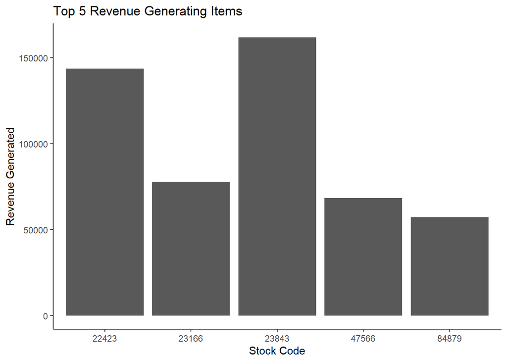

```r
onlineRetailV3 %>%  group_by(StockCode) %>%  summarise(total = sum(totalAmount)) %>%
  arrange(desc(total)) %>%  top_n(5) %>%
  ggplot(aes(x = as.factor(StockCode), y = total)) + geom_col(position = "dodge") +
  labs(x = "Stock Code", y = "Revenue Generated", title = "Top 5 Revenue Generating Items") +
  theme_classic()
```

We observe that the some Items do follow the trend but some do not. Specifically `StockCode 23843` generates the maximum revenue as well as has the highest quantity sold.

What are the monthly sales , you may ask?

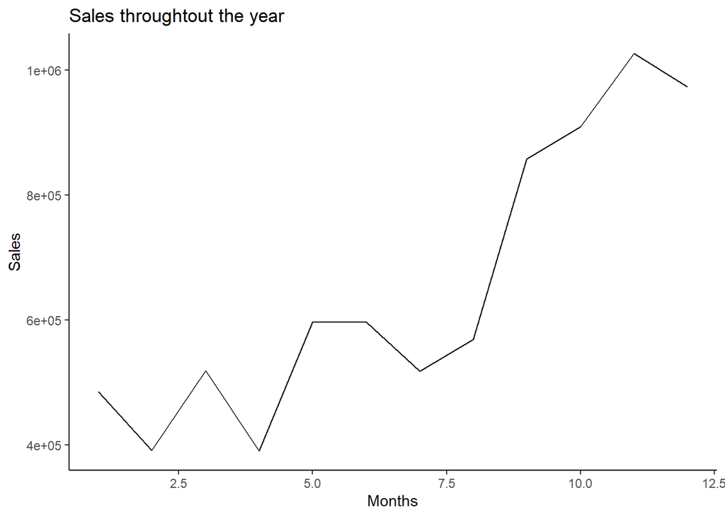

```r
onlineRetailV3 %>%  group_by(month) %>%  summarise(sales = sum(totalAmount)) %>%
  ggplot(aes(x= (month), y= sales)) + geom_line() +
  labs(x= "Months", y= "Sales", title = "Sales throughtout the year") +
  theme_classic()
```

The sales during first quarter the sales are down but see a significant increase during the last quarter with small increment during the middle of the year.

What was the revenue generated throughout the week?

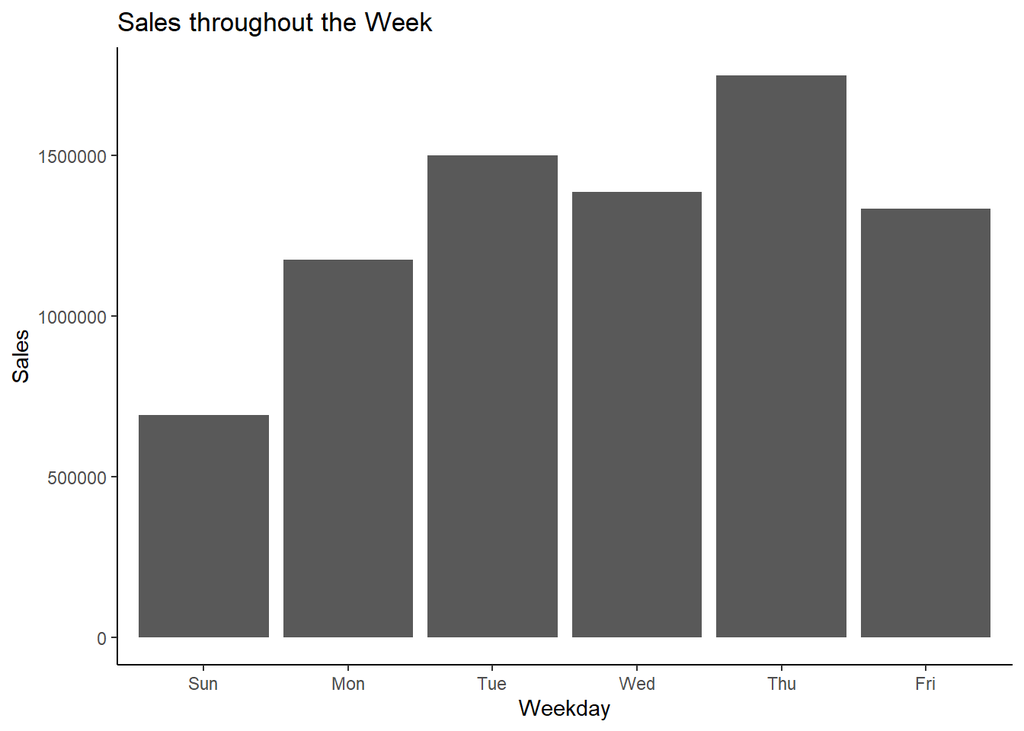

```r
onlineRetailV3 %>% group_by(weekD) %>% summarise(sales = sum(totalAmount)) %>%
  ggplot(aes(x = weekD, y = sales)) + geom_col(position = "dodge") +
  labs(x= "Weekday", y = "Sales", title = "Sales throughout the Week") +
  theme_classic()
```

We see a similar trend to that of the Quantity sold throughout the week.

How many purchases have been made by the customers throughout the year?

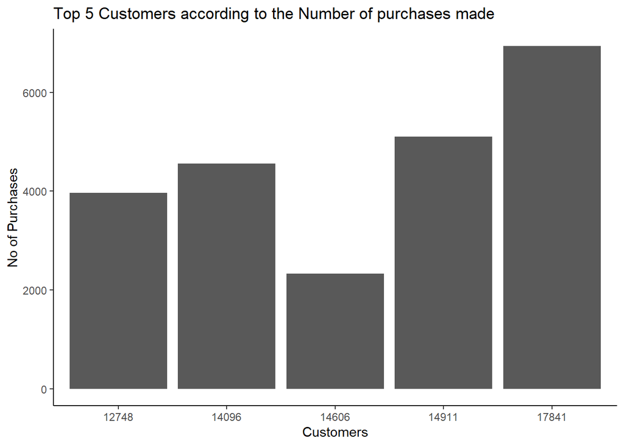

```r
onlineRetailV3 %>%  group_by(CustomerID) %>%  summarise(no = n()) %>%
  filter(no > 1) %>%  arrange(desc(no)) %>%  slice(1:5) %>%
  ggplot(aes(x= as.factor(CustomerID), y= no)) +geom_col(position = "dodge") +
  labs(x= "Customers", y= "No of Purchases",
       title = "Top 5 Customers according to the Number of purchases made")+
  theme_classic()
```

How frequently do the Customers visit us to purchase Items?

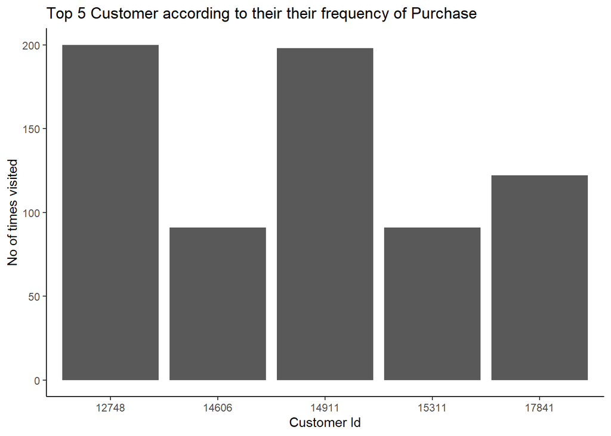

```r
onlineRetailV3 %>%  group_by(CustomerID, InvoiceDate) %>%  summarise(cnt = n()) %>%
  count() %>%  arrange(desc(n)) %>%  ungroup() %>%  top_n(5) %>%
  ggplot(aes(x= as.factor(CustomerID), y= n)) + geom_col(position = "dodge") +
  labs(x= "Customer Id", y="No of times visited",
       title = "Top 5 Customer according to their their frequency of Purchase") +
  theme_classic()
```

We see some interesting things over here that some customers purchase things in a small batch, while some customers visit don’t visit very frequently but purchase a lot of things at once.

## 5 Recommendations

Give special attention to the maximum revenue generating customers, give them offers, treat them specially; which might encourage other customers to do the same, while keeping the older customers loyal. We also see that there our customers purchase from us maximum on the Thursdays and it decreases dramatically on as we reach the weekends, hence we can close our stores/warehouses on those days to cut costs and increase man-power and selling capacity on the week days.